# Ethogram Data Collection 2 - Outcome (Success, Fail)

Marinara Marcato

# 1 Introduction

This document shows the data analysis carried out to investigate the association between ethogram scores filled out by two trainers and the dog’s training outcome. Statistical methods will be used to test the hypothesis that there is a relationship between ethogram scores at DC2 and training outcome (Success, Fail).

# 2 Data Exploration

The dataset comprised of the following types and number of variables. The original ethogram items contained ordinal and categorical variables. The score variables were numerical derived from the original ethogram items.

```
##
## categorical    comments        info     ordinal       score        time
##          17          16          17          53          42          25
##      unused
##          11
```

All ordinal (n=53) and categorical (n=17) variables from the original ethogram items, score (n = 42) variables derived from the original ethogram items and demographical variables (n=2) - namely, Sex and Breed - will be analysed.

## 2.1 Demographics

Overview of the dogs participating in the data collection. Inclusion criteria: only Labrador Retrievers (LR) and Labrador Retrievers crossed with Golden Retrievers (LRxGR) were kept for data analysis.

```
## Original:  61 116
```

```
##
##    GR    LR   LRx LRxGR
##     1    25    12    23
```

```
##
##    LR LRxGR
##    25    35
```

```
## Updated:  60 116
```

```
##
## Success    Fail
##      50      10
```

```
##
##   Success      Fail
## 0.8333333 0.1666667
```

```
##
##  F  M
## 32 28
```

```
## Age at Arrival: Mean 15.28 Standard Deviation 1.88
```

```
## Age at Assessment: Mean 17.81 Standard Deviation 1.84
```

Calculate statistics of duration of training for the dogs that were withdrawn from training. Performing this behaviour test during the training programme (Week 10) would allow assistance dog training organisations to understand which dog are more suitable and allow them to make informed decisions when analysing which dogs to keep for training considering the results of this objective assessment.

```
## [1] "Duration of Training in weeks"
```

```
##     Duration
##  Min.   :10.43
##  1st Qu.:14.21
##  Median :16.29
##  Mean   :17.29
##  3rd Qu.:16.82
##  Max.   :29.57
```

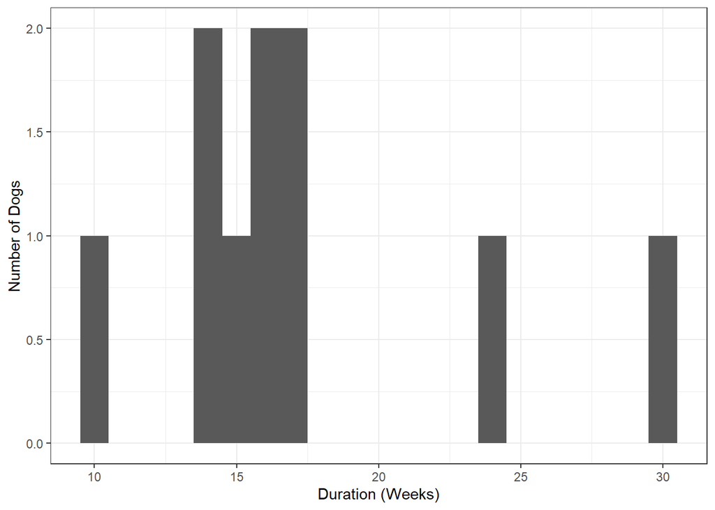

## 2.2 Univariate Logistic regression

Variables whose logistic regression model resulted in p<0.2 when used to predict Outcome are shown. Positive estimates increase the probability of failure, while negative estimates decrease the probability of failure.

```
## [1] "Categorical variable with 2 factors with p<0.02:"
```

```
## [1] estimate_1 p_value_1
## <0 rows> (or 0-length row.names)
```

```
## Categorical variable with 4 factors: Both Left None Righ
```

```
## $Kong.Interaction.Lateralisation
##
## Call:
## glm(formula = Outcome ~ x, family = binomial(link = logit), data = dc_cat,
##     na.action = na.exclude)
##
## Deviance Residuals:
##     Min       1Q   Median       3Q      Max
## -0.9005  -0.5168  -0.4590  -0.4366   2.1899
##
## Coefficients:
##             Estimate Std. Error z value Pr(>|z|)
## (Intercept)  -0.6931     0.6124  -1.132    0.258
## xLeft        -1.2528     0.9728  -1.288    0.198
## xNone        -1.5041     0.9646  -1.559    0.119
## xRigh        -1.6094     1.2143  -1.325    0.185
##
## (Dispersion parameter for binomial family taken to be 1)
##
##     Null deviance: 50.397  on 58  degrees of freedom
## Residual deviance: 47.038  on 55  degrees of freedom
##   (1 observation deleted due to missingness)
## AIC: 55.038
##
## Number of Fisher Scoring iterations: 4
```

[output not shown]

## 2.3 Feature Selection

Selected features based on the univariate logistic regression model results. Whenever both the scores and their original items had p<0.2, the original variables was removed and the scores with lowest p value were kept.

```
##  [1] "Distractions.First.Response..Car."
##  [2] "Distractions.Second.Response..Car."
##  [3] "Crate.Behaviours..Sniffing.Exploring.."
##  [4] "S.Walking.Pull_mean"
##  [5] "S.Walking.Distractions.Pull_mean"
##  [6] "S.Familiarisation.Handler_mean"
##  [7] "S.Sensitivity_mean"
##  [8] "S.Kong.Response_prod"
##  [9] "S.Crate.Handler_mean"
## [10] "S.Isolation.Handler_mean"
## [11] "S.Isolation.Stimulus"
## [12] "Outcome"
```

## 2.4 Missing Data

DC2, missing values per column and per row.

```
##      Distractions.First.Response..Car.     Distractions.Second.Response..Car.
##                                      0                                      0
## Crate.Behaviours..Sniffing.Exploring..                    S.Walking.Pull_mean
##                                      0                                      0
##       S.Walking.Distractions.Pull_mean         S.Familiarisation.Handler_mean
##                                      0                                      1
##                     S.Sensitivity_mean                   S.Kong.Response_prod
##                                      0                                      0
##                   S.Crate.Handler_mean               S.Isolation.Handler_mean
##                                      0                                      0
##                   S.Isolation.Stimulus                                Outcome
##                                      0                                      0
```

```
## dc_row_nas
##  0  1
## 59  1
```

## 2.5 Visualization

I think for the factors, because they are continuous variables (average of discrete variables), it is better to only have the boxplot.

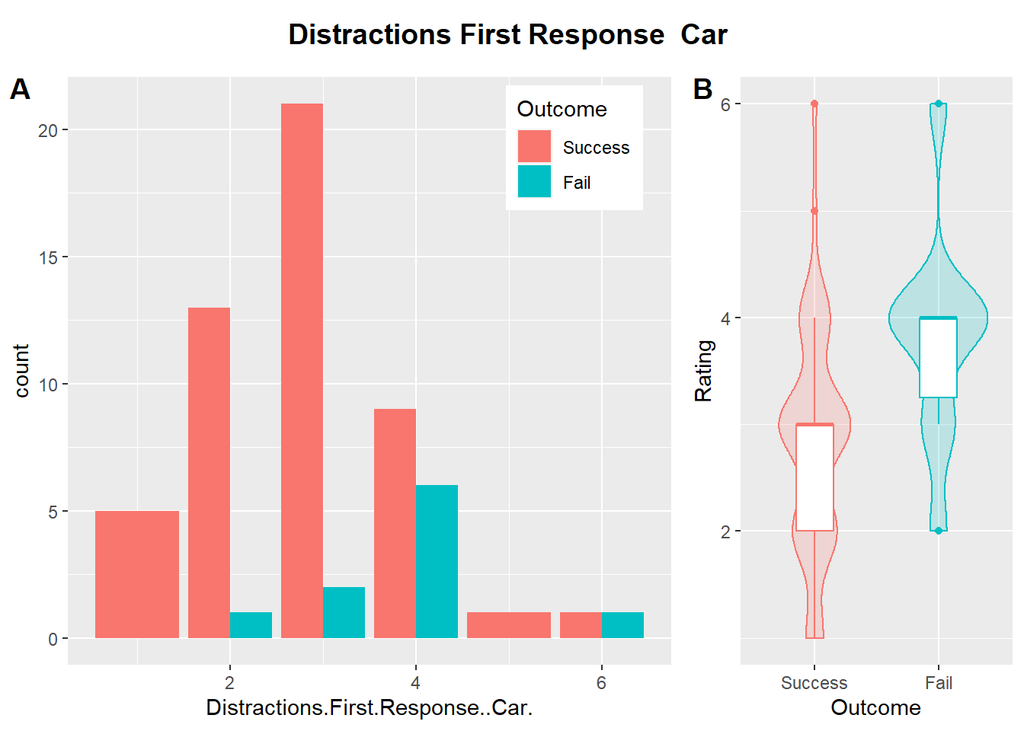

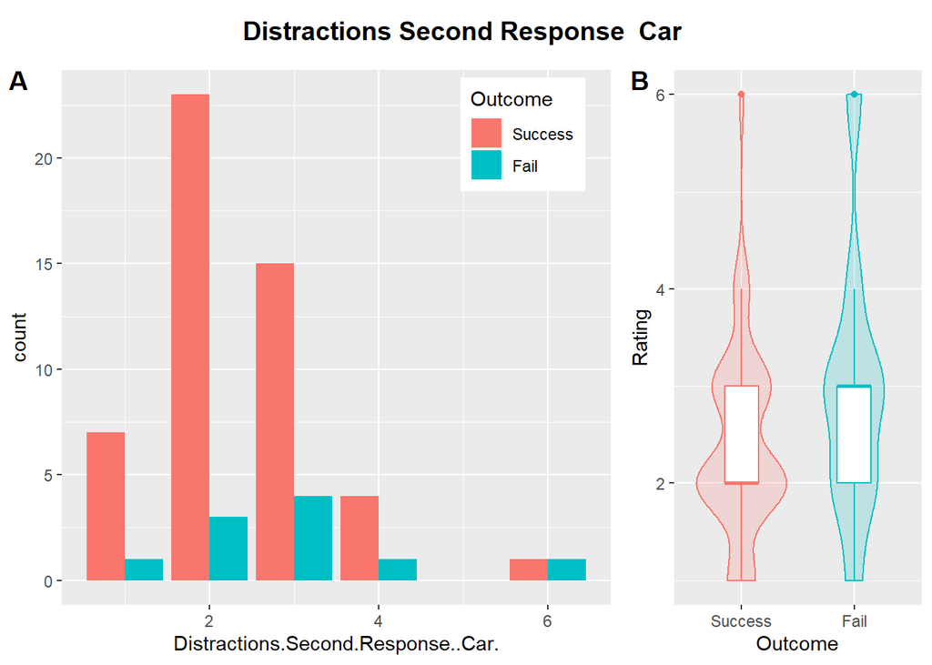

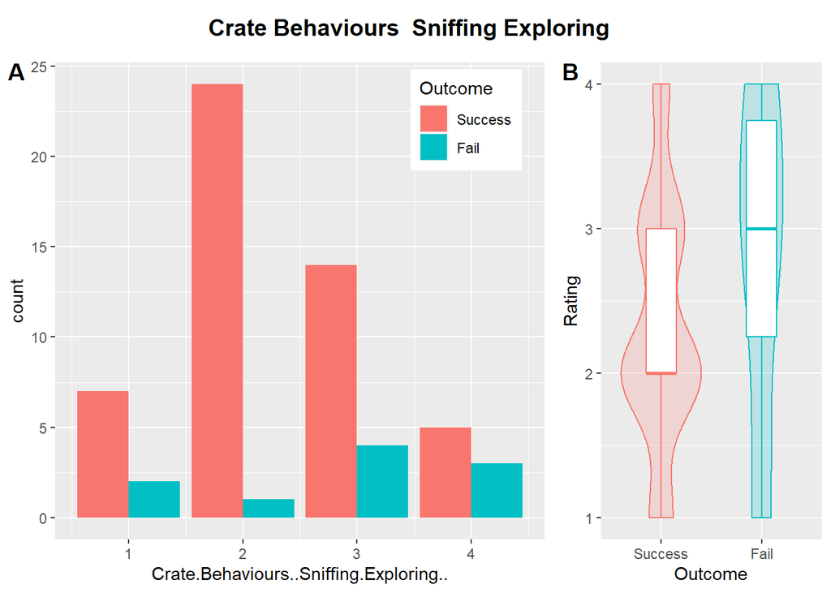

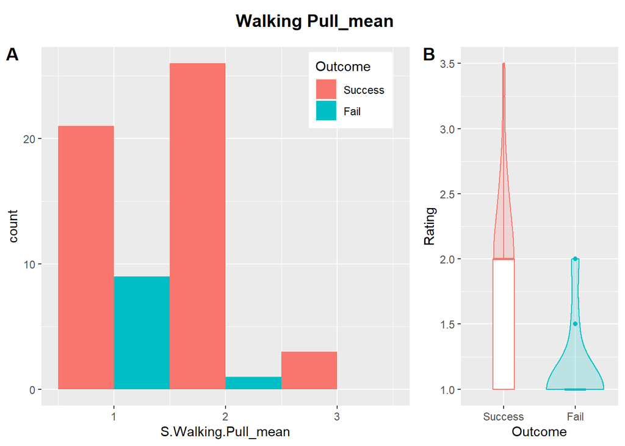

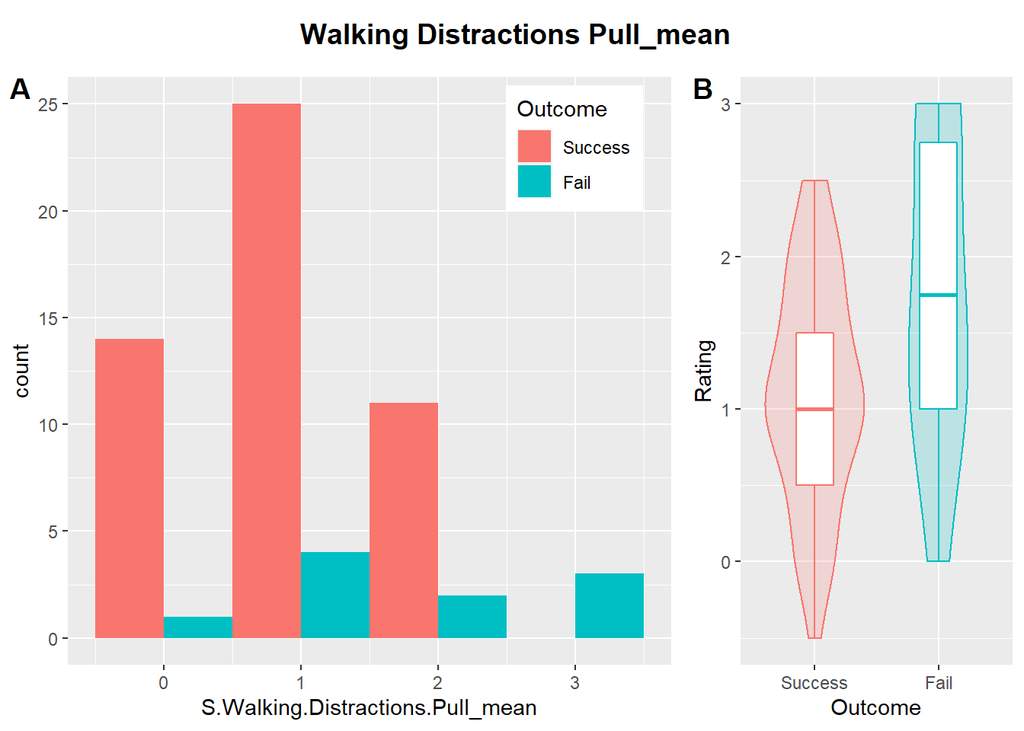

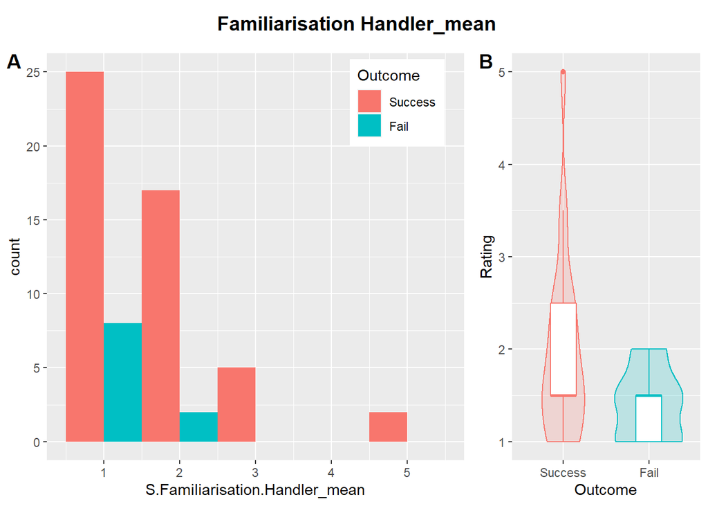

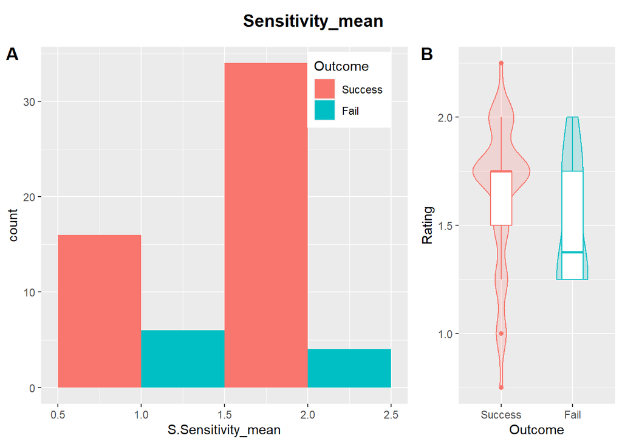

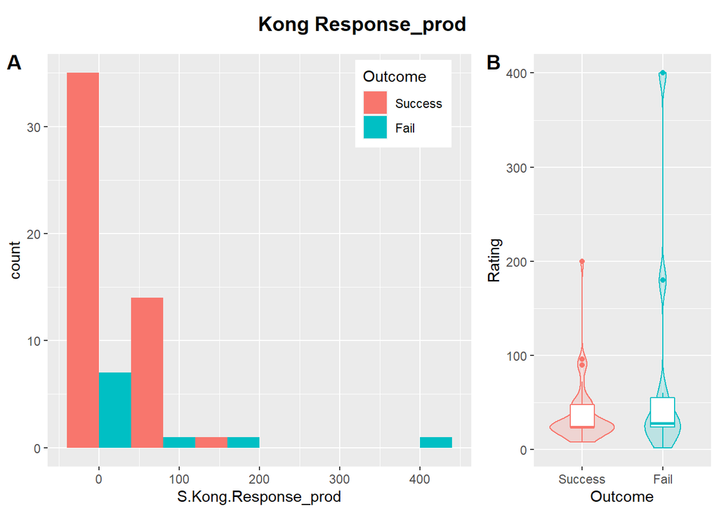

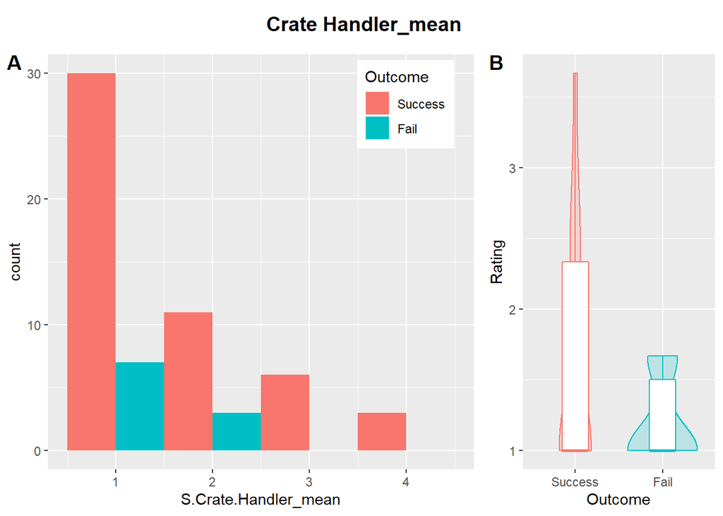

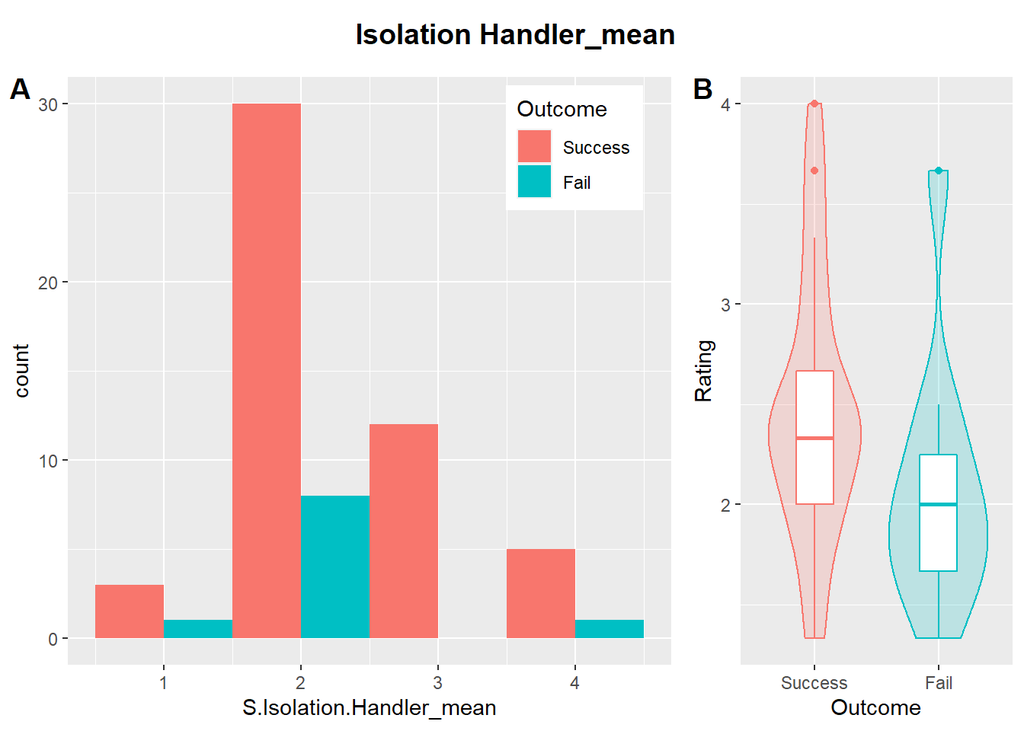

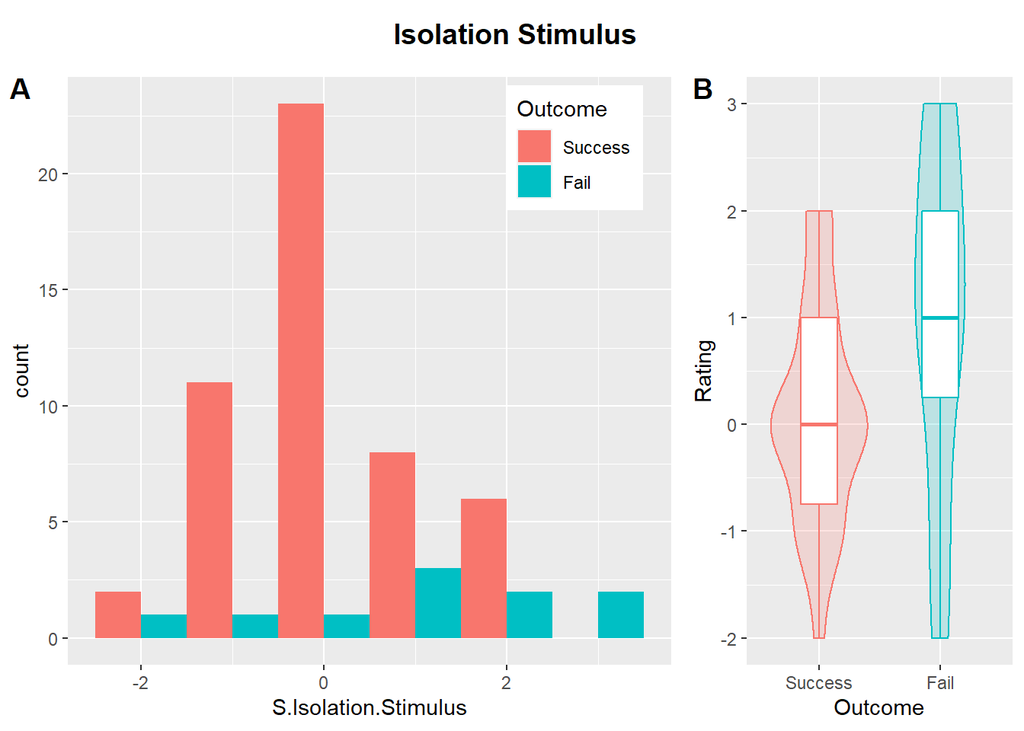

## 2.6 Multicollinearity

The Variance Inflation Factor (VIF) was calculate to assess multicollinearity. VIF = 1 no correlation, 5 < VIF < 10 moderate correlation, VIF > 10 high multicollinearity. VIF larger than 5 or 10 is large and indicate a high level of multicollinearity and should be further processed.

```
##
## Call:
## glm(formula = Outcome ~ ., family = binomial(link = logit), data = dc_sign)
##
## Deviance Residuals:
##        Min          1Q      Median          3Q         Max
## -5.231e-05  -2.100e-08  -2.100e-08  -2.100e-08   5.700e-05
##
## Coefficients:
##                                          Estimate Std. Error z value Pr(>|z|)
## (Intercept)                             1.104e+02  2.557e+05   0.000    1.000
## Distractions.First.Response..Car.       7.233e+01  4.812e+04   0.002    0.999
## Distractions.Second.Response..Car.      6.029e+01  1.098e+05   0.001    1.000
## Crate.Behaviours..Sniffing.Exploring.. -5.739e+01  7.837e+04  -0.001    0.999
## S.Walking.Pull_mean                    -1.888e+02  1.807e+05  -0.001    0.999
## S.Walking.Distractions.Pull_mean        2.960e+01  3.045e+04   0.001    0.999
## S.Familiarisation.Handler_mean         -1.470e+02  8.386e+04  -0.002    0.999
## S.Sensitivity_mean                     -2.744e+01  5.973e+04   0.000    1.000
## S.Kong.Response_prod                   -7.014e-01  5.233e+02  -0.001    0.999
## S.Crate.Handler_mean                   -4.120e+01  4.948e+04  -0.001    0.999
## S.Isolation.Handler_mean                7.859e+01  7.051e+04   0.001    0.999
## S.Isolation.Stimulus                    4.415e+01  7.693e+04   0.001    1.000
##
## (Dispersion parameter for binomial family taken to be 1)
##
##     Null deviance: 5.3699e+01  on 58  degrees of freedom
## Residual deviance: 1.4214e-08  on 47  degrees of freedom
##   (1 observation deleted due to missingness)
## AIC: 24
##
## Number of Fisher Scoring iterations: 25
```

```
##      Distractions.First.Response..Car.     Distractions.Second.Response..Car.
##                              17.197126                             231.002375
## Crate.Behaviours..Sniffing.Exploring..                    S.Walking.Pull_mean
##                              14.695767                             247.391166
##       S.Walking.Distractions.Pull_mean         S.Familiarisation.Handler_mean
##                              11.240426                              20.148783
##                     S.Sensitivity_mean                   S.Kong.Response_prod
##                               9.561533                              12.527096
##                   S.Crate.Handler_mean               S.Isolation.Handler_mean
##                               8.744131                              19.537401
##                   S.Isolation.Stimulus
##                              36.361341
```

# 3 Multivariate Model

## 3.1 Preprocessing: Normalization + Imputation + PCA

## 3.2 Recursive Feature Elimination (RFE) + Multivariate Logistic Regression (LR)

```
## [1] "Original dataset"
```

```
## 'data.frame':    60 obs. of  12 variables:
##  $ Distractions.First.Response..Car.     : int  4 3 4 2 1 2 3 3 6 3 ...
##  $ Distractions.Second.Response..Car.    : num  3 3 2 2 3 2 3 2 6 3 ...
##  $ Crate.Behaviours..Sniffing.Exploring..: num  3 1 3 1 2 1 2 4 3 3 ...
##  $ S.Walking.Pull_mean                   : num  1 1 1 1 1.5 3.5 2.5 1 3.5 3 ...
##  $ S.Walking.Distractions.Pull_mean      : num  1 3 0 1 1 0 0.5 3 1 0 ...
##  $ S.Familiarisation.Handler_mean        : num  2.5 1 1.5 1.5 2 3 1 1 1 3 ...
##  $ S.Sensitivity_mean                    : num  1.25 1.25 1.25 1.75 1.5 1.75 2 1.25 1.75 1.75 ...
##  $ S.Kong.Response_prod                  : num  24 400 24 48 12 24 12 180 24 48 ...
##  $ S.Crate.Handler_mean                  : num  1 1 1.67 1 2.67 ...
##  $ S.Isolation.Handler_mean              : num  2 1.67 2 2 2.67 ...
##  $ S.Isolation.Stimulus                  : num  0 1 1 0 0 -1 0 2 0 0 ...
##  $ Outcome                               : Factor w/ 2 levels "Success","Fail": 1 2 2 1 1 1 1 2 1 1 ...
```

```
## [1] "PCA dataset"
```

```
## tibble [60 × 11] (S3: tbl_df/tbl/data.frame)
##  $ Outcome: Factor w/ 2 levels "Success","Fail": 1 2 2 1 1 1 1 2 1 1 ...
##  $ PC01   : num [1:60] 0.249 1.354 0.832 1.28 -0.107 ...
##  $ PC02   : num [1:60] 1.135 3.849 0.86 -0.476 -1.322 ...
##  $ PC03   : num [1:60] -1.068 2.657 -0.929 0.351 0.815 ...
##  $ PC04   : num [1:60] 1.399 -3.171 0.926 -0.939 -0.119 ...
##  $ PC05   : num [1:60] -0.615 -2.713 -0.274 0.274 -0.74 ...
##  $ PC06   : num [1:60] -0.23 -2.428 1.431 -0.659 1.057 ...
##  $ PC07   : num [1:60] 0.373 -1.52 -0.244 0.636 0.213 ...
##  $ PC08   : num [1:60] 0.282 0.291 0.21 0.618 0.216 ...
##  $ PC09   : num [1:60] -0.252 0.282 0.34 -0.476 -1.243 ...
##  $ PC10   : num [1:60] -0.3922 -0.1305 -1.2046 -1.101 0.0304 ...
```

```
## [1] "Modelling"
```

```
##
## Recursive feature selection
##
## Outer resampling method: Leave-One-Out Cross-Validation
##
## Resampling performance over subset size:
##
##  Variables   ROC Sens Spec Selected
##          1 0.902 0.98  0.6        *
##          2 0.872 0.96  0.7
##          3 0.878 0.94  0.7
##          4 0.792 0.90  0.5
##          5 0.792 0.90  0.6
##          6 0.707 0.88  0.6
##          7 0.654 0.88  0.7
##          8 0.646 0.86  0.6
##          9 0.596 0.86  0.6
##         10 0.728 0.88  0.6
##
## The top 1 variables (out of 1):
##    PC02
##
##
## Call:
## glm(formula = Class ~ ., family = "binomial", data = tmp)
##
## Deviance Residuals:
##      Min        1Q    Median        3Q       Max
## -1.48747  -0.36278  -0.22386  -0.06318   2.35926
##
## Coefficients:
##             Estimate Std. Error z value Pr(>|z|)
## (Intercept)  -2.8561     0.7228  -3.951 7.78e-05 ***
## PC02          1.9419     0.5996   3.239   0.0012 **
## ---
## Signif. codes:  0 '***' 0.001 '**' 0.01 '*' 0.05 '.' 0.1 ' ' 1
##
## (Dispersion parameter for binomial family taken to be 1)
##
##     Null deviance: 54.067  on 59  degrees of freedom
## Residual deviance: 28.532  on 58  degrees of freedom
## AIC: 32.532
##
## Number of Fisher Scoring iterations: 6
```

```
##
## deviance difference:  25.5356
## df difference:  1
## level of significance:  0.9999996
## the model is a good fit:  TRUE
```

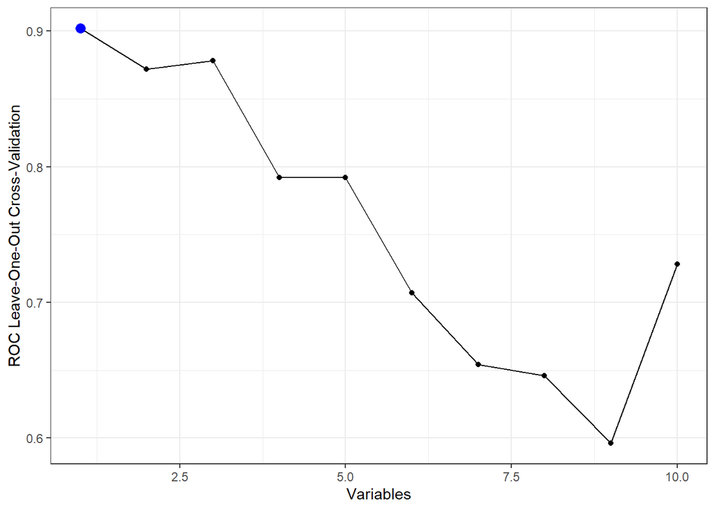

## 3.3 Interpretation

```
## [1] "Results from the model created"
```

```
##              Estimate Std. Error   z value    Pr(>|z|)         OR       2.5 %
## (Intercept) -2.856102  0.7228432 -3.951206 7.77584e-05 0.05749241 0.009769822
## PC02         1.941932  0.5996222  3.238593 1.20121e-03 6.97220926 2.681535242
##                 97.5 %
## (Intercept)  0.1853083
## PC02        30.3429871
```

```
## [1] "Probability predicted by the LR using DC2 ethogram data vs true Outcome"
```

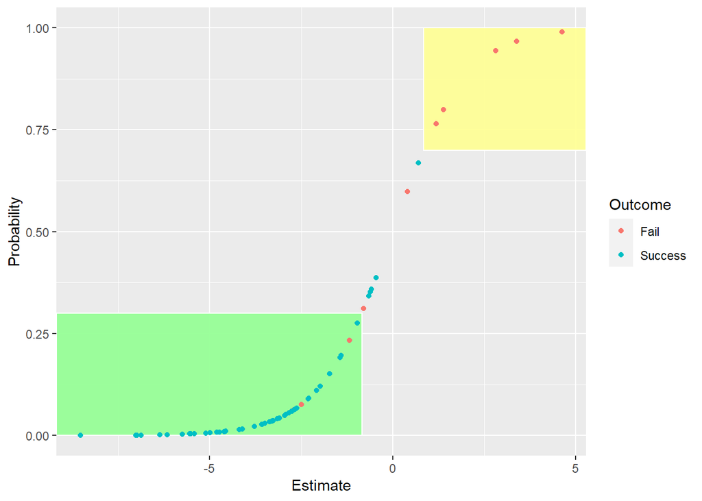

```
## [1] "Probability predicted by the LR using DC2 ethogram data vs true Status"
```

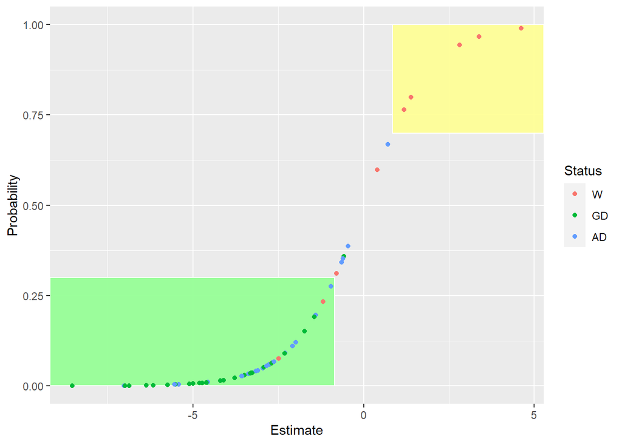

```
## Predicted probability < 0.3  -> Green flag
```

```
## [1] "Dogs flagged green are likely to SUCCEED, true outcome count and status proportion:"
```

```
##
##    Fail Success
##       3      45
```

```
##
##         W        GD        AD
## 0.0625000 0.5416667 0.3958333
```

```
## Predicted probability > 0.7 -> Yellow flag
```

[output not shown]

```
##
##    Fail Success
##       5       0
```

```
##
##  W GD AD
##  1  0  0
```

## 3.4 Feature Importance

### 3.4.1 Explained variance

```
## PCA features kept in the final model after RFE:  PC02
```

```
## [1] "Explained Variance per Principal Component (Scree Plot)"
```

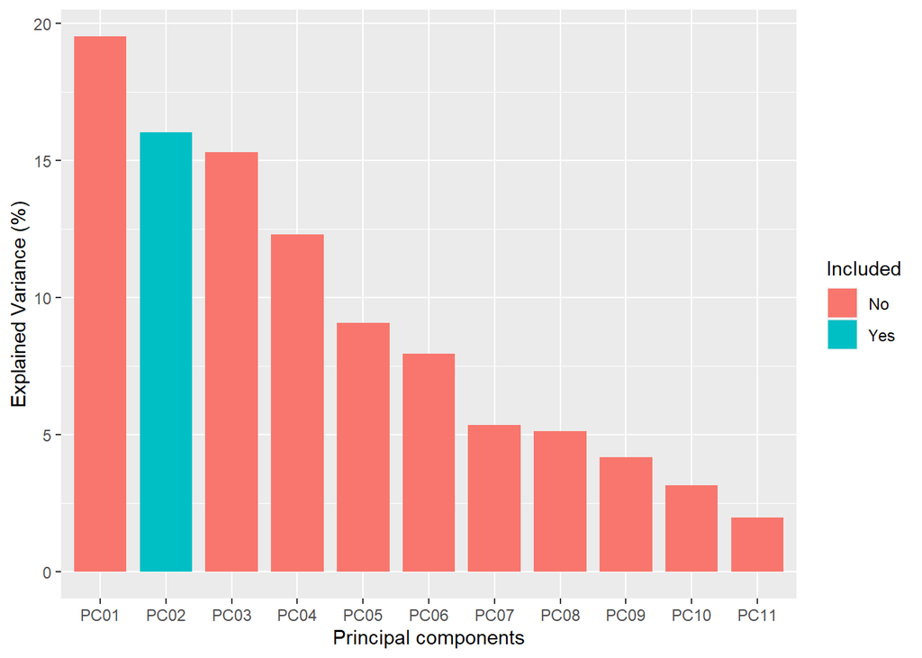

### 3.4.2 Coefficient loadings

```
##                                     terms      value
## 1       Distractions.First.Response..Car.  0.4128931
## 2        S.Walking.Distractions.Pull_mean  0.3740523
## 3                S.Isolation.Handler_mean -0.3653173
## 4                    S.Kong.Response_prod  0.3018132
## 5  Crate.Behaviours..Sniffing.Exploring..  0.2916611
## 6          S.Familiarisation.Handler_mean -0.2916230
## 7                      S.Sensitivity_mean -0.2843316
## 8                     S.Walking.Pull_mean -0.2702027
## 9                    S.Isolation.Stimulus  0.2501497
## 10     Distractions.Second.Response..Car.  0.2339752
## 11                   S.Crate.Handler_mean -0.1541846
```

```
## Principal Component PC02 vs Original Variables
```

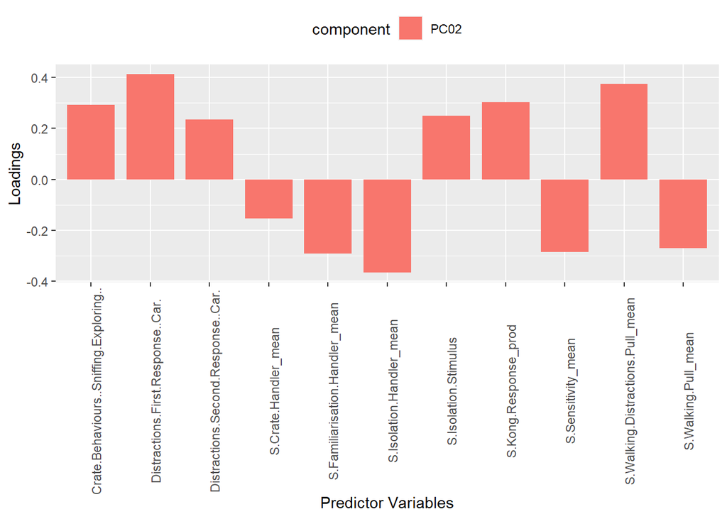

# 4 Conclusion